# R Data Wrangling (cont.)

In this session, we will continue practicing `dplyr` functions for data manipulation. We’ll work with the **`nycflights13`** dataset to explore and analyze data about flights departing from New York City in 2013. We’ll practice using the `select()`, `filter()`, `mutate()`, `summarize()`, `arrange()`, `if_else()`, and `case_when()` functions, as well as learning how to combine data with various types of **joins** (`left_join()`). Then we’ll create a function to help with a repetitive task.

## Business Scenario

Suppose you are a data analyst working for an airline company. You need to analyze flight data to understand delays and where the largest impacts occurred. You have access to flight data, airline information, and airport data.

## Data Overview

### Flights Data (`flights`)

| Column | Description |
| --- | --- |
| year | Year of the flight (2013). |
| month | Month of the flight. |
| day | Day of the flight. |
| dep_time | Departure time. |
| sched_dep_time | Scheduled departure time. |
| dep_delay | Departure delay (in minutes). |
| arr_time | Arrival time. |
| sched_arr_time | Scheduled arrival time. |
| arr_delay | Arrival delay (in minutes). |
| carrier | Two-letter carrier abbreviation. |
| flight | Flight number. |
| tailnum | Plane tail number. |
| origin | Origin airport. |
| dest | Destination airport. |
| air_time | Air time (in minutes). |
| distance | Distance flown (in miles). |
| hour | Hour of scheduled departure. |
| minute | Minute of scheduled departure. |
| time_hour | Scheduled departure time as a POSIXct date-time object. |

### Airlines Data (`airlines`)

| Column | Description |
| --- | --- |
| carrier | Two-letter carrier abbreviation. |
| name | Full name of the airline. |

### Airports Data (`airports`)

| Column | Description |
| --- | --- |
| faa | FAA airport code. |
| name | Usual name of the airport. |
| lat | Latitude of the airport. |
| lon | Longitude of the airport. |
| alt | Altitude of the airport, in feet. |
| tz | Timezone offset from GMT. |
| dst | Daylight savings time zone. |
| tzone | IANA time zone name. |

## Load the `dplyr` and `nycflights13` packages

If `dplyr` or `nycflights13` are not installed, first install with the code `install.packages('dplyr')` and `install.packages('nycflights13')`.

Look at all three datasets using the `head()` function. **In RStudio, you may have to first type `data(flights)`, `data(airlines)`, and `data(airports)` to load the data into your local environment and then use the `head()` function.**

## Review

### Exercise 1: Mutate

Create a new column total_delay by adding dep_delay and arr_delay.

Update the dataset so that the new column is saved and can be recalled later.

### Exercise 2: Summarize

Calculate the average departure delay across all the data.

Calculate the average departure delay by month.

## Exercise 3: Filter and Arrange

Filter for the American Airlines carrier and sort the data by dep_delay in descending order. Select just the year, month, day, dep_delay, carrier, origin, and dest columns. View the first 10 rows.

## Conditional Statements: `if_else`

An “if else” statement is used to execute different blocks of code based on whether a condition is TRUE or FALSE. The basic syntax is:

```
if (condition) {
  # Code to execute if condition is TRUE
} else {
  # Code to execute if condition is FALSE
}
```

### Exercise 4: Create a new column using `if_else`

Create a new column that categorizes flights as “On Time” if they departed on time or “Delayed” if they were delayed.

## Conditional Statements: `case_when`

The `case_when()` function in R, part of the dplyr package, is a powerful tool for creating new variables based on multiple conditions. It is similar to a series of `if_else()` statements but more concise and readable. The basic syntax is:

```
df %>%
  mutate(new_var = case_when(
    condition1 ~ value1,
    condition2 ~ value2,
    TRUE ~ default_value
  ))
```

### Exercise 5: Create a new column using `case_when`

Create a new column that categorizes flights based on their departure delay:

- On Time: Departure delay is 0 or less.
- Short Delay: Departure delay is between 1 and 15 minutes.
- Medium Delay: Departure delay is between 15 and 60 minutes.
- Long Delay: Departure delay is more than 60 minutes.

In this example:

- dep_delay <= 0 ~ “On Time” assigns “On Time” to flights with no delay or early departure.
- dep_delay > 0 & dep_delay <= 15 ~ “Short Delay” assigns “Short Delay” to flights delayed by up to 15 minutes.
- dep_delay > 15 & dep_delay <= 60 ~ “Medium Delay” assigns “Medium Delay” to flights delayed by up to 60 minutes.
- dep_delay > 60 ~ “Long Delay” assigns “Long Delay” to flights delayed by more than 60 minutes.
- TRUE ~ “Unknown” acts as a catch-all for any other cases, ensuring no missing values.

## Joins

Joins are used to combine data from two data frames based on a common column. The `dplyr` package provides several types of joins, each serving a different purpose.

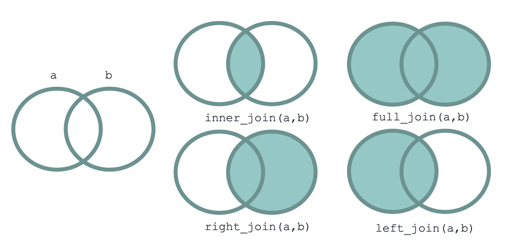

https://atorus-research.github.io/intro_to_r_website/slides.html

- **Inner Join**: An inner join returns only the rows that have matching values in both data frames.
- **Left Join**: A left join returns all rows from the left data frame and the matched rows from the right data frame. If there is no match, the result is NA on the right side.
- **Right Join**: A right join returns all rows from the right data frame and the matched rows from the left data frame. If there is no match, the result is NA on the left side.
- **Full Join**: A full join returns all rows when there is a match in either left or right data frame. Rows without a match in one of the data frames will have NA in the respective columns.

### Exercise 6: Add origin airport information to the `flights` data

We use a left join to keep all of the `flights` records even if the airport does not exist in the `airports` data. We’ll start with the `flights` data as our main data (like table a in the visual above). Then we’ll `left_join` `airports` to bring in more information. In this join, `origin` in the `flights` data frame maps to the `faa` code in the `airports` data frame, so this is what we specify in the “by” statement of the join.

Left join with specifying the `name` column as `origin_name`.

## Functions

A **function** in R is a block of code that performs a specific task. Functions help avoid repeating code and can make your code more organized and reusable. You can think of a function like a “mini-program” that you can call whenever you need to do a certain task.

A function typically has:

- A **name**: What you call the function (e.g., `mean()`, `filter()`).
- **Arguments**: The inputs you pass into the function (e.g., a dataset, a value).
- **Body**: The block of code that gets executed when the function is called.
- **Return value**: What the function gives back after it finishes.

### Exercise 7: Create a simple function `total_delay`

Create a function `total_delay` that calculates the total delay by adding dep_delay and arr_delay. Then, use this function within a mutate call to add a `tot_delay` column to the flights data frame.

### Example of a more complex Function

Create a function to calculate the average departure delay for a specific airline as an input.

You can reuse this function for any airline by changing the airline_code argument. This makes your code more modular and easy to work with.